# Risk Factor Analysis

## Outcome Variable

**Outcome Variable:** sstunted

## Predictor Variables

**Intervention Variable:** mage

**Adjustment Set:**

- arm
- meducyrs
- feducyrs
- W_mhtcm
- W_mwtkg
- W_mbmi
- single
- delta_meducyrs
- delta_feducyrs
- delta_W_mhtcm
- delta_W_mwtkg
- delta_W_mbmi
- delta_single

## Stratifying Variables

The analysis was stratified on these variable(s):

- agecat
- studyid
- country

## Data Summary

| agecat | studyid | country | mage | sstunted | n_cell | n |
| --- | --- | --- | --- | --- | --- | --- |
| Birth | ki0047075b-MAL-ED | BANGLADESH | [20-30) | 0 | 154 | 231 |
| Birth | ki0047075b-MAL-ED | BANGLADESH | [20-30) | 1 | 6 | 231 |
| Birth | ki0047075b-MAL-ED | BANGLADESH | <20 | 0 | 29 | 231 |
| Birth | ki0047075b-MAL-ED | BANGLADESH | <20 | 1 | 1 | 231 |
| Birth | ki0047075b-MAL-ED | BANGLADESH | >=30 | 0 | 39 | 231 |
| Birth | ki0047075b-MAL-ED | BANGLADESH | >=30 | 1 | 2 | 231 |
| Birth | ki0047075b-MAL-ED | BRAZIL | [20-30) | 0 | 39 | 65 |
| Birth | ki0047075b-MAL-ED | BRAZIL | [20-30) | 1 | 2 | 65 |
| Birth | ki0047075b-MAL-ED | BRAZIL | <20 | 0 | 8 | 65 |
| Birth | ki0047075b-MAL-ED | BRAZIL | <20 | 1 | 0 | 65 |
| Birth | ki0047075b-MAL-ED | BRAZIL | >=30 | 0 | 15 | 65 |
| Birth | ki0047075b-MAL-ED | BRAZIL | >=30 | 1 | 1 | 65 |
| Birth | ki0047075b-MAL-ED | INDIA | [20-30) | 0 | 36 | 47 |
| Birth | ki0047075b-MAL-ED | INDIA | [20-30) | 1 | 1 | 47 |
| Birth | ki0047075b-MAL-ED | INDIA | <20 | 0 | 7 | 47 |
| Birth | ki0047075b-MAL-ED | INDIA | <20 | 1 | 1 | 47 |
| Birth | ki0047075b-MAL-ED | INDIA | >=30 | 0 | 2 | 47 |
| Birth | ki0047075b-MAL-ED | INDIA | >=30 | 1 | 0 | 47 |
| Birth | ki0047075b-MAL-ED | NEPAL | [20-30) | 0 | 21 | 27 |
| Birth | ki0047075b-MAL-ED | NEPAL | [20-30) | 1 | 1 | 27 |
| Birth | ki0047075b-MAL-ED | NEPAL | <20 | 0 | 0 | 27 |
| Birth | ki0047075b-MAL-ED | NEPAL | <20 | 1 | 0 | 27 |
| Birth | ki0047075b-MAL-ED | NEPAL | >=30 | 0 | 5 | 27 |
| Birth | ki0047075b-MAL-ED | NEPAL | >=30 | 1 | 0 | 27 |
| Birth | ki0047075b-MAL-ED | PERU | [20-30) | 0 | 114 | 233 |
| Birth | ki0047075b-MAL-ED | PERU | [20-30) | 1 | 0 | 233 |
| Birth | ki0047075b-MAL-ED | PERU | <20 | 0 | 63 | 233 |
| Birth | ki0047075b-MAL-ED | PERU | <20 | 1 | 3 | 233 |
| Birth | ki0047075b-MAL-ED | PERU | >=30 | 0 | 52 | 233 |
| Birth | ki0047075b-MAL-ED | PERU | >=30 | 1 | 1 | 233 |

[output cut: 396 more lines]

The following strata were considered:

- agecat: 24 months, studyid: ki0047075b-MAL-ED, country: BANGLADESH
- agecat: 24 months, studyid: ki0047075b-MAL-ED, country: BRAZIL
- agecat: 24 months, studyid: ki0047075b-MAL-ED, country: INDIA
- agecat: 24 months, studyid: ki0047075b-MAL-ED, country: NEPAL
- agecat: 24 months, studyid: ki0047075b-MAL-ED, country: PERU
- agecat: 24 months, studyid: ki0047075b-MAL-ED, country: SOUTH AFRICA
- agecat: 24 months, studyid: ki0047075b-MAL-ED, country: TANZANIA, UNITED REPUBLIC OF
- agecat: 24 months, studyid: ki1000108-CMC-V-BCS-2002, country: INDIA
- agecat: 24 months, studyid: ki1000108-IRC, country: INDIA
- agecat: 24 months, studyid: ki1000109-EE, country: PAKISTAN
- agecat: 24 months, studyid: ki1017093-NIH-Birth, country: BANGLADESH
- agecat: 24 months, studyid: ki1017093b-PROVIDE, country: BANGLADESH
- agecat: 24 months, studyid: ki1017093c-NIH-Crypto, country: BANGLADESH
- agecat: 24 months, studyid: ki1066203-TanzaniaChild2, country: TANZANIA, UNITED REPUBLIC OF
- agecat: 24 months, studyid: ki1101329-Keneba, country: GAMBIA
- agecat: 24 months, studyid: ki1113344-GMS-Nepal, country: NEPAL
- agecat: 24 months, studyid: ki1119695-PROBIT, country: BELARUS
- agecat: 24 months, studyid: ki1126311-ZVITAMBO, country: ZIMBABWE
- agecat: 24 months, studyid: ki1135781-COHORTS, country: GUATEMALA
- agecat: 24 months, studyid: ki1135781-COHORTS, country: INDIA
- agecat: 24 months, studyid: ki1135781-COHORTS, country: PHILIPPINES
- agecat: 24 months, studyid: ki1148112-LCNI-5, country: MALAWI
- agecat: 24 months, studyid: kiGH5241-JiVitA-3, country: BANGLADESH
- agecat: 6 months, studyid: ki0047075b-MAL-ED, country: BANGLADESH
- agecat: 6 months, studyid: ki0047075b-MAL-ED, country: BRAZIL
- agecat: 6 months, studyid: ki0047075b-MAL-ED, country: INDIA
- agecat: 6 months, studyid: ki0047075b-MAL-ED, country: NEPAL
- agecat: 6 months, studyid: ki0047075b-MAL-ED, country: PERU
- agecat: 6 months, studyid: ki0047075b-MAL-ED, country: SOUTH AFRICA
- agecat: 6 months, studyid: ki0047075b-MAL-ED, country: TANZANIA, UNITED REPUBLIC OF
- agecat: 6 months, studyid: ki1000108-CMC-V-BCS-2002, country: INDIA
- agecat: 6 months, studyid: ki1000108-IRC, country: INDIA
- agecat: 6 months, studyid: ki1000109-EE, country: PAKISTAN
- agecat: 6 months, studyid: ki1000304b-SAS-CompFeed, country: INDIA
- agecat: 6 months, studyid: ki1000304b-SAS-FoodSuppl, country: INDIA
- agecat: 6 months, studyid: ki1017093-NIH-Birth, country: BANGLADESH
- agecat: 6 months, studyid: ki1017093b-PROVIDE, country: BANGLADESH
- agecat: 6 months, studyid: ki1017093c-NIH-Crypto, country: BANGLADESH
- agecat: 6 months, studyid: ki1066203-TanzaniaChild2, country: TANZANIA, UNITED REPUBLIC OF
- agecat: 6 months, studyid: ki1101329-Keneba, country: GAMBIA
- agecat: 6 months, studyid: ki1112895-Guatemala BSC, country: GUATEMALA
- agecat: 6 months, studyid: ki1113344-GMS-Nepal, country: NEPAL
- agecat: 6 months, studyid: ki1119695-PROBIT, country: BELARUS
- agecat: 6 months, studyid: ki1126311-ZVITAMBO, country: ZIMBABWE
- agecat: 6 months, studyid: ki1135781-COHORTS, country: GUATEMALA
- agecat: 6 months, studyid: ki1135781-COHORTS, country: INDIA
- agecat: 6 months, studyid: ki1135781-COHORTS, country: PHILIPPINES
- agecat: 6 months, studyid: ki1148112-LCNI-5, country: MALAWI
- agecat: 6 months, studyid: kiGH5241-JiVitA-3, country: BANGLADESH
- agecat: Birth, studyid: ki0047075b-MAL-ED, country: BANGLADESH
- agecat: Birth, studyid: ki0047075b-MAL-ED, country: BRAZIL
- agecat: Birth, studyid: ki0047075b-MAL-ED, country: INDIA
- agecat: Birth, studyid: ki0047075b-MAL-ED, country: NEPAL
- agecat: Birth, studyid: ki0047075b-MAL-ED, country: PERU
- agecat: Birth, studyid: ki0047075b-MAL-ED, country: SOUTH AFRICA
- agecat: Birth, studyid: ki0047075b-MAL-ED, country: TANZANIA, UNITED REPUBLIC OF
- agecat: Birth, studyid: ki1000108-CMC-V-BCS-2002, country: INDIA
- agecat: Birth, studyid: ki1000108-IRC, country: INDIA
- agecat: Birth, studyid: ki1000109-EE, country: PAKISTAN
- agecat: Birth, studyid: ki1000304b-SAS-CompFeed, country: INDIA
- agecat: Birth, studyid: ki1017093-NIH-Birth, country: BANGLADESH
- agecat: Birth, studyid: ki1017093b-PROVIDE, country: BANGLADESH
- agecat: Birth, studyid: ki1017093c-NIH-Crypto, country: BANGLADESH
- agecat: Birth, studyid: ki1101329-Keneba, country: GAMBIA
- agecat: Birth, studyid: ki1113344-GMS-Nepal, country: NEPAL
- agecat: Birth, studyid: ki1119695-PROBIT, country: BELARUS
- agecat: Birth, studyid: ki1126311-ZVITAMBO, country: ZIMBABWE
- agecat: Birth, studyid: ki1135781-COHORTS, country: GUATEMALA
- agecat: Birth, studyid: ki1135781-COHORTS, country: INDIA
- agecat: Birth, studyid: ki1135781-COHORTS, country: PHILIPPINES
- agecat: Birth, studyid: kiGH5241-JiVitA-3, country: BANGLADESH

### Dropped Strata

Some strata were dropped due to rare outcomes:

- agecat: Birth, studyid: ki0047075b-MAL-ED, country: BANGLADESH
- agecat: Birth, studyid: ki0047075b-MAL-ED, country: BRAZIL
- agecat: Birth, studyid: ki0047075b-MAL-ED, country: INDIA
- agecat: Birth, studyid: ki0047075b-MAL-ED, country: NEPAL
- agecat: Birth, studyid: ki0047075b-MAL-ED, country: PERU
- agecat: Birth, studyid: ki0047075b-MAL-ED, country: SOUTH AFRICA
- agecat: Birth, studyid: ki0047075b-MAL-ED, country: TANZANIA, UNITED REPUBLIC OF
- agecat: Birth, studyid: ki1000108-CMC-V-BCS-2002, country: INDIA
- agecat: Birth, studyid: ki1000108-IRC, country: INDIA
- agecat: Birth, studyid: ki1000109-EE, country: PAKISTAN
- agecat: Birth, studyid: ki1017093-NIH-Birth, country: BANGLADESH
- agecat: Birth, studyid: ki1017093b-PROVIDE, country: BANGLADESH
- agecat: Birth, studyid: ki1017093c-NIH-Crypto, country: BANGLADESH
- agecat: Birth, studyid: ki1113344-GMS-Nepal, country: NEPAL
- agecat: Birth, studyid: ki1119695-PROBIT, country: BELARUS
- agecat: Birth, studyid: ki1135781-COHORTS, country: GUATEMALA
- agecat: 6 months, studyid: ki0047075b-MAL-ED, country: BANGLADESH
- agecat: 6 months, studyid: ki0047075b-MAL-ED, country: BRAZIL
- agecat: 6 months, studyid: ki0047075b-MAL-ED, country: INDIA
- agecat: 6 months, studyid: ki0047075b-MAL-ED, country: NEPAL
- agecat: 6 months, studyid: ki0047075b-MAL-ED, country: PERU
- agecat: 6 months, studyid: ki0047075b-MAL-ED, country: SOUTH AFRICA
- agecat: 6 months, studyid: ki0047075b-MAL-ED, country: TANZANIA, UNITED REPUBLIC OF
- agecat: 6 months, studyid: ki1000108-CMC-V-BCS-2002, country: INDIA
- agecat: 6 months, studyid: ki1000108-IRC, country: INDIA
- agecat: 6 months, studyid: ki1000109-EE, country: PAKISTAN
- agecat: 6 months, studyid: ki1017093-NIH-Birth, country: BANGLADESH
- agecat: 6 months, studyid: ki1017093b-PROVIDE, country: BANGLADESH
- agecat: 6 months, studyid: ki1066203-TanzaniaChild2, country: TANZANIA, UNITED REPUBLIC OF
- agecat: 6 months, studyid: ki1101329-Keneba, country: GAMBIA
- agecat: 6 months, studyid: ki1112895-Guatemala BSC, country: GUATEMALA
- agecat: 6 months, studyid: ki1148112-LCNI-5, country: MALAWI
- agecat: 24 months, studyid: ki0047075b-MAL-ED, country: BRAZIL
- agecat: 24 months, studyid: ki0047075b-MAL-ED, country: INDIA
- agecat: 24 months, studyid: ki0047075b-MAL-ED, country: NEPAL
- agecat: 24 months, studyid: ki0047075b-MAL-ED, country: PERU
- agecat: 24 months, studyid: ki0047075b-MAL-ED, country: SOUTH AFRICA
- agecat: 24 months, studyid: ki0047075b-MAL-ED, country: TANZANIA, UNITED REPUBLIC OF
- agecat: 24 months, studyid: ki1000108-IRC, country: INDIA
- agecat: 24 months, studyid: ki1000109-EE, country: PAKISTAN
- agecat: 24 months, studyid: ki1017093-NIH-Birth, country: BANGLADESH
- agecat: 24 months, studyid: ki1017093c-NIH-Crypto, country: BANGLADESH
- agecat: 24 months, studyid: ki1066203-TanzaniaChild2, country: TANZANIA, UNITED REPUBLIC OF

## Methods Detail

We’re interested in the causal parameters $E[Y_a]$ for all values of $a \in \mathcal{A}$. These parameters represent the mean outcome if, possibly contrary to fact, we intervened to set all units to have $A=a$. Under the randomization and positivity assumptions, these are identified by the statistical parameters $\psi_a=E_W[E_{Y|A,W}(Y|A=a,W)]$. In addition, we’re interested in the mean of $Y$, $E[Y]$ under no intervention (the observed mean). We will estimate these parameters by using SuperLearner to fit the relevant likelihood factors – $E_{Y|A,W}(Y|A=a,W)$ and $p(A=a|W)$, and then updating our likelihood fit using a joint TMLE.

For unadjusted analyses ($W=\{\}$), initial likelihoods were estimated using Lrnr_glm to estimate the simple $E(Y|A)$ and Lrnr_mean to estimate $p(A)$. For adjusted analyses, a small library containing Lrnr_glmnet, Lrnr_xgboost, and Lrnr_mean was used.

Having estimated these parameters, we will then use the delta method to estimate relative risks and attributable risks relative to a prespecified baseline level of $A$.

# Results Detail

## Results Plots

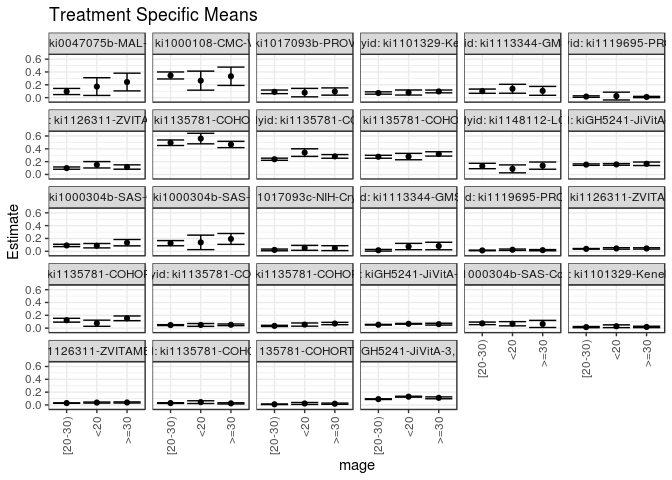

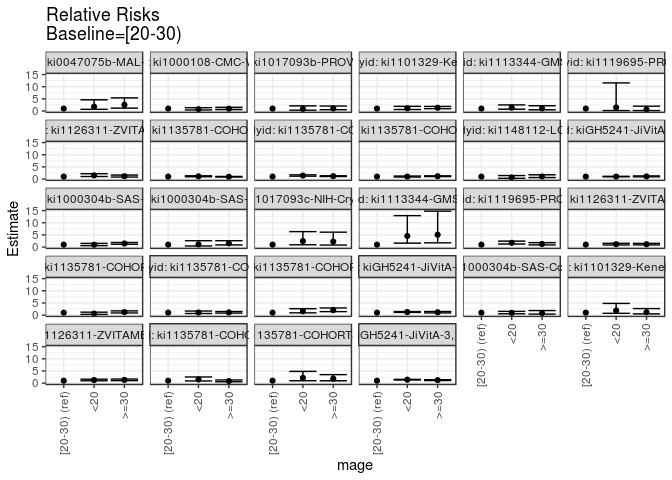

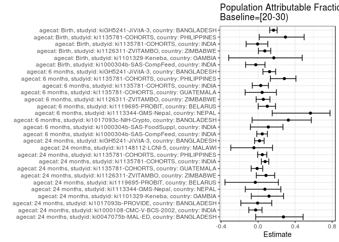

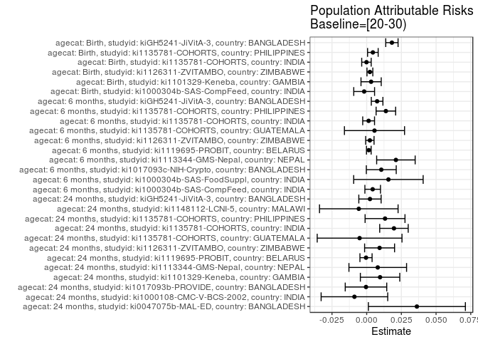

## Results Table

### Parameter: TSM

| agecat | studyid | country | intervention_level | baseline_level | estimate | ci_lower | ci_upper |
| --- | --- | --- | --- | --- | --- | --- | --- |
| Birth | ki1000304b-SAS-CompFeed | INDIA | [20-30) | NA | 0.0745016 | 0.0544113 | 0.0945918 |
| Birth | ki1000304b-SAS-CompFeed | INDIA | <20 | NA | 0.0683230 | 0.0354638 | 0.1011821 |
| Birth | ki1000304b-SAS-CompFeed | INDIA | >=30 | NA | 0.0652174 | 0.0097255 | 0.1207093 |
| Birth | ki1101329-Keneba | GAMBIA | [20-30) | NA | 0.0156028 | 0.0064516 | 0.0247541 |
| Birth | ki1101329-Keneba | GAMBIA | <20 | NA | 0.0294118 | 0.0079395 | 0.0508841 |
| Birth | ki1101329-Keneba | GAMBIA | >=30 | NA | 0.0183333 | 0.0075955 | 0.0290711 |
| Birth | ki1126311-ZVITAMBO | ZIMBABWE | [20-30) | NA | 0.0294884 | 0.0260358 | 0.0329410 |
| Birth | ki1126311-ZVITAMBO | ZIMBABWE | <20 | NA | 0.0374291 | 0.0290549 | 0.0458033 |
| Birth | ki1126311-ZVITAMBO | ZIMBABWE | >=30 | NA | 0.0389754 | 0.0305530 | 0.0473977 |
| Birth | ki1135781-COHORTS | INDIA | [20-30) | NA | 0.0294285 | 0.0234869 | 0.0353701 |
| Birth | ki1135781-COHORTS | INDIA | <20 | NA | 0.0442915 | 0.0229092 | 0.0656739 |
| Birth | ki1135781-COHORTS | INDIA | >=30 | NA | 0.0252081 | 0.0160403 | 0.0343759 |
| Birth | ki1135781-COHORTS | PHILIPPINES | [20-30) | NA | 0.0106244 | 0.0059341 | 0.0153147 |
| Birth | ki1135781-COHORTS | PHILIPPINES | <20 | NA | 0.0232529 | 0.0079799 | 0.0385259 |
| Birth | ki1135781-COHORTS | PHILIPPINES | >=30 | NA | 0.0195021 | 0.0102963 | 0.0287079 |
| Birth | kiGH5241-JiVitA-3 | BANGLADESH | [20-30) | NA | 0.0908464 | 0.0849592 | 0.0967337 |
| Birth | kiGH5241-JiVitA-3 | BANGLADESH | <20 | NA | 0.1288542 | 0.1214311 | 0.1362772 |
| Birth | kiGH5241-JiVitA-3 | BANGLADESH | >=30 | NA | 0.1111818 | 0.0966639 | 0.1256997 |
| 6 months | ki1000304b-SAS-CompFeed | INDIA | [20-30) | NA | 0.0914844 | 0.0734120 | 0.1095568 |
| 6 months | ki1000304b-SAS-CompFeed | INDIA | <20 | NA | 0.0872646 | 0.0532341 | 0.1212951 |
| 6 months | ki1000304b-SAS-CompFeed | INDIA | >=30 | NA | 0.1340974 | 0.0845372 | 0.1836576 |
| 6 months | ki1000304b-SAS-FoodSuppl | INDIA | [20-30) | NA | 0.1264368 | 0.0860644 | 0.1668091 |
| 6 months | ki1000304b-SAS-FoodSuppl | INDIA | <20 | NA | 0.1388889 | 0.0257707 | 0.2520071 |
| 6 months | ki1000304b-SAS-FoodSuppl | INDIA | >=30 | NA | 0.1927711 | 0.1077943 | 0.2777479 |
| 6 months | ki1017093c-NIH-Crypto | BANGLADESH | [20-30) | NA | 0.0216450 | 0.0083662 | 0.0349238 |
| 6 months | ki1017093c-NIH-Crypto | BANGLADESH | <20 | NA | 0.0534351 | 0.0148957 | 0.0919745 |
| 6 months | ki1017093c-NIH-Crypto | BANGLADESH | >=30 | NA | 0.0491803 | 0.0107816 | 0.0875791 |
| 6 months | ki1113344-GMS-Nepal | NEPAL | [20-30) | NA | 0.0161725 | 0.0033257 | 0.0290193 |
| 6 months | ki1113344-GMS-Nepal | NEPAL | <20 | NA | 0.0740741 | 0.0246381 | 0.1235100 |
| 6 months | ki1113344-GMS-Nepal | NEPAL | >=30 | NA | 0.0823529 | 0.0238603 | 0.1408456 |

[output cut: 54 more lines]

### Parameter: E(Y)

| agecat | studyid | country | intervention_level | baseline_level | estimate | ci_lower | ci_upper |
| --- | --- | --- | --- | --- | --- | --- | --- |
| Birth | ki1000304b-SAS-CompFeed | INDIA | NA | NA | 0.0726837 | 0.0523147 | 0.0930527 |
| Birth | ki1101329-Keneba | GAMBIA | NA | NA | 0.0187946 | 0.0120166 | 0.0255726 |
| Birth | ki1126311-ZVITAMBO | ZIMBABWE | NA | NA | 0.0318034 | 0.0288793 | 0.0347275 |
| Birth | ki1135781-COHORTS | INDIA | NA | NA | 0.0292683 | 0.0244566 | 0.0340800 |
| Birth | ki1135781-COHORTS | PHILIPPINES | NA | NA | 0.0150820 | 0.0107558 | 0.0194081 |
| Birth | kiGH5241-JiVitA-3 | BANGLADESH | NA | NA | 0.1090269 | 0.1044770 | 0.1135768 |
| 6 months | ki1000304b-SAS-CompFeed | INDIA | NA | NA | 0.0958084 | 0.0774939 | 0.1141229 |
| 6 months | ki1000304b-SAS-FoodSuppl | INDIA | NA | NA | 0.1421053 | 0.1069532 | 0.1772573 |
| 6 months | ki1017093c-NIH-Crypto | BANGLADESH | NA | NA | 0.0321678 | 0.0192256 | 0.0451101 |
| 6 months | ki1113344-GMS-Nepal | NEPAL | NA | NA | 0.0372340 | 0.0215945 | 0.0528736 |
| 6 months | ki1119695-PROBIT | BELARUS | NA | NA | 0.0154178 | 0.0100323 | 0.0208033 |
| 6 months | ki1126311-ZVITAMBO | ZIMBABWE | NA | NA | 0.0404484 | 0.0362972 | 0.0445996 |
| 6 months | ki1135781-COHORTS | GUATEMALA | NA | NA | 0.1290323 | 0.1078261 | 0.1502384 |
| 6 months | ki1135781-COHORTS | INDIA | NA | NA | 0.0487357 | 0.0427089 | 0.0547626 |
| 6 months | ki1135781-COHORTS | PHILIPPINES | NA | NA | 0.0487445 | 0.0406327 | 0.0568562 |
| 6 months | kiGH5241-JiVitA-3 | BANGLADESH | NA | NA | 0.0606962 | 0.0568440 | 0.0645485 |
| 24 months | ki0047075b-MAL-ED | BANGLADESH | NA | NA | 0.1320755 | 0.0863920 | 0.1777589 |
| 24 months | ki1000108-CMC-V-BCS-2002 | INDIA | NA | NA | 0.3369272 | 0.2887662 | 0.3850883 |
| 24 months | ki1017093b-PROVIDE | BANGLADESH | NA | NA | 0.0899654 | 0.0666186 | 0.1133122 |
| 24 months | ki1101329-Keneba | GAMBIA | NA | NA | 0.0816803 | 0.0687107 | 0.0946498 |
| 24 months | ki1113344-GMS-Nepal | NEPAL | NA | NA | 0.1086066 | 0.0809724 | 0.1362407 |
| 24 months | ki1119695-PROBIT | BELARUS | NA | NA | 0.0161090 | 0.0034156 | 0.0288025 |
| 24 months | ki1126311-ZVITAMBO | ZIMBABWE | NA | NA | 0.1086691 | 0.0935928 | 0.1237455 |
| 24 months | ki1135781-COHORTS | GUATEMALA | NA | NA | 0.4896617 | 0.4596107 | 0.5197126 |
| 24 months | ki1135781-COHORTS | INDIA | NA | NA | 0.2573131 | 0.2432102 | 0.2714161 |
| 24 months | ki1135781-COHORTS | PHILIPPINES | NA | NA | 0.2891616 | 0.2711872 | 0.3071359 |
| 24 months | ki1148112-LCNI-5 | MALAWI | NA | NA | 0.1263158 | 0.0964093 | 0.1562223 |
| 24 months | kiGH5241-JiVitA-3 | BANGLADESH | NA | NA | 0.1560218 | 0.1472599 | 0.1647837 |

### Parameter: RR

| agecat | studyid | country | intervention_level | baseline_level | estimate | ci_lower | ci_upper |
| --- | --- | --- | --- | --- | --- | --- | --- |
| Birth | ki1000304b-SAS-CompFeed | INDIA | [20-30) | [20-30) | 1.0000000 | 1.0000000 | 1.000000 |
| Birth | ki1000304b-SAS-CompFeed | INDIA | <20 | [20-30) | 0.9170676 | 0.5472881 | 1.536692 |
| Birth | ki1000304b-SAS-CompFeed | INDIA | >=30 | [20-30) | 0.8753827 | 0.4108343 | 1.865216 |
| Birth | ki1101329-Keneba | GAMBIA | [20-30) | [20-30) | 1.0000000 | 1.0000000 | 1.000000 |
| Birth | ki1101329-Keneba | GAMBIA | <20 | [20-30) | 1.8850267 | 0.7389454 | 4.808645 |
| Birth | ki1101329-Keneba | GAMBIA | >=30 | [20-30) | 1.1750000 | 0.5129324 | 2.691632 |
| Birth | ki1126311-ZVITAMBO | ZIMBABWE | [20-30) | [20-30) | 1.0000000 | 1.0000000 | 1.000000 |
| Birth | ki1126311-ZVITAMBO | ZIMBABWE | <20 | [20-30) | 1.2692816 | 0.9861555 | 1.633693 |
| Birth | ki1126311-ZVITAMBO | ZIMBABWE | >=30 | [20-30) | 1.3217177 | 1.0337306 | 1.689935 |
| Birth | ki1135781-COHORTS | INDIA | [20-30) | [20-30) | 1.0000000 | 1.0000000 | 1.000000 |
| Birth | ki1135781-COHORTS | INDIA | <20 | [20-30) | 1.5050543 | 0.8917565 | 2.540142 |
| Birth | ki1135781-COHORTS | INDIA | >=30 | [20-30) | 0.8565874 | 0.5650475 | 1.298549 |
| Birth | ki1135781-COHORTS | PHILIPPINES | [20-30) | [20-30) | 1.0000000 | 1.0000000 | 1.000000 |
| Birth | ki1135781-COHORTS | PHILIPPINES | <20 | [20-30) | 2.1886331 | 0.9921656 | 4.827939 |
| Birth | ki1135781-COHORTS | PHILIPPINES | >=30 | [20-30) | 1.8355951 | 0.9620459 | 3.502337 |
| Birth | kiGH5241-JiVitA-3 | BANGLADESH | [20-30) | [20-30) | 1.0000000 | 1.0000000 | 1.000000 |
| Birth | kiGH5241-JiVitA-3 | BANGLADESH | <20 | [20-30) | 1.4183734 | 1.3053980 | 1.541126 |
| Birth | kiGH5241-JiVitA-3 | BANGLADESH | >=30 | [20-30) | 1.2238437 | 1.0553228 | 1.419275 |
| 6 months | ki1000304b-SAS-CompFeed | INDIA | [20-30) | [20-30) | 1.0000000 | 1.0000000 | 1.000000 |
| 6 months | ki1000304b-SAS-CompFeed | INDIA | <20 | [20-30) | 0.9538746 | 0.6003987 | 1.515454 |
| 6 months | ki1000304b-SAS-CompFeed | INDIA | >=30 | [20-30) | 1.4657958 | 1.1454899 | 1.875667 |
| 6 months | ki1000304b-SAS-FoodSuppl | INDIA | [20-30) | [20-30) | 1.0000000 | 1.0000000 | 1.000000 |
| 6 months | ki1000304b-SAS-FoodSuppl | INDIA | <20 | [20-30) | 1.0984848 | 0.4580048 | 2.634621 |
| 6 months | ki1000304b-SAS-FoodSuppl | INDIA | >=30 | [20-30) | 1.5246440 | 0.8846589 | 2.627611 |
| 6 months | ki1017093c-NIH-Crypto | BANGLADESH | [20-30) | [20-30) | 1.0000000 | 1.0000000 | 1.000000 |
| 6 months | ki1017093c-NIH-Crypto | BANGLADESH | <20 | [20-30) | 2.4687023 | 0.9577527 | 6.363324 |
| 6 months | ki1017093c-NIH-Crypto | BANGLADESH | >=30 | [20-30) | 2.2721311 | 0.8417772 | 6.132953 |
| 6 months | ki1113344-GMS-Nepal | NEPAL | [20-30) | [20-30) | 1.0000000 | 1.0000000 | 1.000000 |
| 6 months | ki1113344-GMS-Nepal | NEPAL | <20 | [20-30) | 4.5802463 | 1.6229586 | 12.926181 |
| 6 months | ki1113344-GMS-Nepal | NEPAL | >=30 | [20-30) | 5.0921562 | 1.7543677 | 14.780285 |

[output cut: 54 more lines]

### Parameter: PAR

| agecat | studyid | country | intervention_level | baseline_level | estimate | ci_lower | ci_upper |
| --- | --- | --- | --- | --- | --- | --- | --- |
| Birth | ki1000304b-SAS-CompFeed | INDIA | [20-30) | NA | -0.0018179 | -0.0093166 | 0.0056808 |
| Birth | ki1101329-Keneba | GAMBIA | [20-30) | NA | 0.0031917 | -0.0040994 | 0.0104828 |
| Birth | ki1126311-ZVITAMBO | ZIMBABWE | [20-30) | NA | 0.0023150 | 0.0002057 | 0.0044242 |
| Birth | ki1135781-COHORTS | INDIA | [20-30) | NA | -0.0001602 | -0.0035785 | 0.0032580 |
| Birth | ki1135781-COHORTS | PHILIPPINES | [20-30) | NA | 0.0044576 | 0.0006385 | 0.0082767 |
| Birth | kiGH5241-JiVitA-3 | BANGLADESH | [20-30) | NA | 0.0181805 | 0.0137465 | 0.0226145 |
| 6 months | ki1000304b-SAS-CompFeed | INDIA | [20-30) | NA | 0.0043240 | -0.0012965 | 0.0099445 |
| 6 months | ki1000304b-SAS-FoodSuppl | INDIA | [20-30) | NA | 0.0156685 | -0.0093633 | 0.0407002 |
| 6 months | ki1017093c-NIH-Crypto | BANGLADESH | [20-30) | NA | 0.0105228 | -0.0002457 | 0.0212913 |
| 6 months | ki1113344-GMS-Nepal | NEPAL | [20-30) | NA | 0.0210615 | 0.0071868 | 0.0349363 |
| 6 months | ki1119695-PROBIT | BELARUS | [20-30) | NA | 0.0015349 | -0.0001521 | 0.0032219 |
| 6 months | ki1126311-ZVITAMBO | ZIMBABWE | [20-30) | NA | 0.0022907 | -0.0007291 | 0.0053106 |
| 6 months | ki1135781-COHORTS | GUATEMALA | [20-30) | NA | 0.0056280 | -0.0160294 | 0.0272854 |
| 6 months | ki1135781-COHORTS | INDIA | [20-30) | NA | 0.0013993 | -0.0028569 | 0.0056556 |
| 6 months | ki1135781-COHORTS | PHILIPPINES | [20-30) | NA | 0.0138326 | 0.0067938 | 0.0208714 |
| 6 months | kiGH5241-JiVitA-3 | BANGLADESH | [20-30) | NA | 0.0075150 | 0.0033377 | 0.0116924 |
| 24 months | ki0047075b-MAL-ED | BANGLADESH | [20-30) | NA | 0.0361851 | 0.0012263 | 0.0711438 |
| 24 months | ki1000108-CMC-V-BCS-2002 | INDIA | [20-30) | NA | -0.0088355 | -0.0328345 | 0.0151635 |
| 24 months | ki1017093b-PROVIDE | BANGLADESH | [20-30) | NA | -0.0004991 | -0.0154533 | 0.0144550 |
| 24 months | ki1101329-Keneba | GAMBIA | [20-30) | NA | 0.0096473 | -0.0045577 | 0.0238522 |
| 24 months | ki1113344-GMS-Nepal | NEPAL | [20-30) | NA | 0.0079776 | -0.0127925 | 0.0287478 |
| 24 months | ki1119695-PROBIT | BELARUS | [20-30) | NA | -0.0004827 | -0.0048602 | 0.0038948 |
| 24 months | ki1126311-ZVITAMBO | ZIMBABWE | [20-30) | NA | 0.0093013 | -0.0014901 | 0.0200927 |
| 24 months | ki1135781-COHORTS | GUATEMALA | [20-30) | NA | -0.0051087 | -0.0356566 | 0.0254391 |
| 24 months | ki1135781-COHORTS | INDIA | [20-30) | NA | 0.0196560 | 0.0093844 | 0.0299275 |
| 24 months | ki1135781-COHORTS | PHILIPPINES | [20-30) | NA | 0.0132327 | -0.0011432 | 0.0276086 |
| 24 months | ki1148112-LCNI-5 | MALAWI | [20-30) | NA | -0.0056842 | -0.0339957 | 0.0226273 |
| 24 months | kiGH5241-JiVitA-3 | BANGLADESH | [20-30) | NA | 0.0023680 | -0.0056704 | 0.0104064 |

### Parameter: PAF

| agecat | studyid | country | intervention_level | baseline_level | estimate | ci_lower | ci_upper |
| --- | --- | --- | --- | --- | --- | --- | --- |
| Birth | ki1000304b-SAS-CompFeed | INDIA | [20-30) | NA | -0.0250107 | -0.1355116 | 0.0747370 |
| Birth | ki1101329-Keneba | GAMBIA | [20-30) | NA | 0.1698215 | -0.3171959 | 0.4767700 |
| Birth | ki1126311-ZVITAMBO | ZIMBABWE | [20-30) | NA | 0.0727906 | 0.0043062 | 0.1365645 |
| Birth | ki1135781-COHORTS | INDIA | [20-30) | NA | -0.0054741 | -0.1293076 | 0.1047805 |
| Birth | ki1135781-COHORTS | PHILIPPINES | [20-30) | NA | 0.2955564 | 0.0124747 | 0.4974906 |
| Birth | kiGH5241-JiVitA-3 | BANGLADESH | [20-30) | NA | 0.1667523 | 0.1254840 | 0.2060731 |
| 6 months | ki1000304b-SAS-CompFeed | INDIA | [20-30) | NA | 0.0451319 | -0.0142363 | 0.1010249 |
| 6 months | ki1000304b-SAS-FoodSuppl | INDIA | [20-30) | NA | 0.1102597 | -0.0827152 | 0.2688402 |
| 6 months | ki1017093c-NIH-Crypto | BANGLADESH | [20-30) | NA | 0.3271222 | -0.0651509 | 0.5749291 |
| 6 months | ki1113344-GMS-Nepal | NEPAL | [20-30) | NA | 0.5656526 | 0.1524749 | 0.7774017 |
| 6 months | ki1119695-PROBIT | BELARUS | [20-30) | NA | 0.0995518 | 0.0007205 | 0.1886084 |
| 6 months | ki1126311-ZVITAMBO | ZIMBABWE | [20-30) | NA | 0.0566333 | -0.0209067 | 0.1282840 |
| 6 months | ki1135781-COHORTS | GUATEMALA | [20-30) | NA | 0.0436170 | -0.1397263 | 0.1974666 |
| 6 months | ki1135781-COHORTS | INDIA | [20-30) | NA | 0.0287129 | -0.0626016 | 0.1121803 |
| 6 months | ki1135781-COHORTS | PHILIPPINES | [20-30) | NA | 0.2837775 | 0.1326772 | 0.4085539 |
| 6 months | kiGH5241-JiVitA-3 | BANGLADESH | [20-30) | NA | 0.1238136 | 0.0525996 | 0.1896746 |
| 24 months | ki0047075b-MAL-ED | BANGLADESH | [20-30) | NA | 0.2739726 | -0.0260551 | 0.4862695 |
| 24 months | ki1000108-CMC-V-BCS-2002 | INDIA | [20-30) | NA | -0.0262237 | -0.0999876 | 0.0425936 |
| 24 months | ki1017093b-PROVIDE | BANGLADESH | [20-30) | NA | -0.0055482 | -0.1862916 | 0.1476570 |
| 24 months | ki1101329-Keneba | GAMBIA | [20-30) | NA | 0.1181101 | -0.0732362 | 0.2753415 |
| 24 months | ki1113344-GMS-Nepal | NEPAL | [20-30) | NA | 0.0734544 | -0.1380845 | 0.2456739 |
| 24 months | ki1119695-PROBIT | BELARUS | [20-30) | NA | -0.0299662 | -0.3577463 | 0.2186829 |
| 24 months | ki1126311-ZVITAMBO | ZIMBABWE | [20-30) | NA | 0.0855930 | -0.0190011 | 0.1794512 |
| 24 months | ki1135781-COHORTS | GUATEMALA | [20-30) | NA | -0.0104332 | -0.0747755 | 0.0500572 |
| 24 months | ki1135781-COHORTS | INDIA | [20-30) | NA | 0.0763893 | 0.0356861 | 0.1153744 |
| 24 months | ki1135781-COHORTS | PHILIPPINES | [20-30) | NA | 0.0457622 | -0.0052791 | 0.0942121 |
| 24 months | ki1148112-LCNI-5 | MALAWI | [20-30) | NA | -0.0450000 | -0.2947642 | 0.1565839 |
| 24 months | kiGH5241-JiVitA-3 | BANGLADESH | [20-30) | NA | 0.0151772 | -0.0376552 | 0.0653196 |